# LdaQdaNB

Marcela

6 de agosto de 2020

Comenzaremos analizando el ejemplo de la clase de los lirios. Tenemos 150 observaciones, 50 de cada especie, los datos con los que contamos son los anchos y largos de los petalos y sepalos de las flores. Separamos la muestra de entrenamiento, que tendra el $75\%$ de los datos y la de validacion que tiene el $25\%$ restante.

```r
set.seed(789)
training_sample <- sample(c(TRUE, FALSE), nrow(iris), replace = T, prob = c(0.75,0.25))
train <- iris[training_sample, ]
test <- iris[!training_sample, ]
```

Buscamos la funcion discriminante lineal para la muestra de entrenamiento.

```r
lda.iris = lda(Species ~ ., train)

lda.iris$means # vector de medias para cada grupo.
```

```
##            Sepal.Length Sepal.Width Petal.Length Petal.Width
## setosa         5.020455    3.454545     1.463636   0.2386364
## versicolor     5.947222    2.766667     4.280556   1.3305556
## virginica      6.572222    2.988889     5.536111   2.0333333
```

```r
lda.iris$scaling # pesos de las hiperplanos separadores.
```

```
##                     LD1        LD2
## Sepal.Length  0.6995002 -0.2271531
## Sepal.Width   1.8998145  2.2000344
## Petal.Length -2.4957982 -0.7635871
## Petal.Width  -2.8973110  2.7018827
```

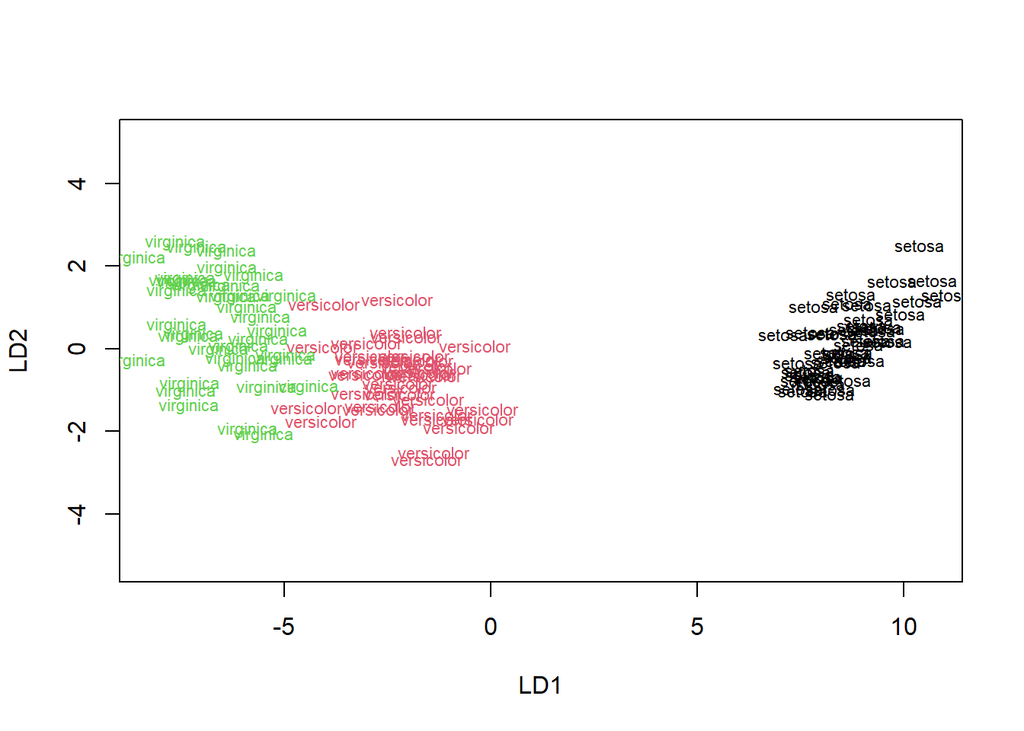

```r
plot(lda.iris,col=as.integer(train$Species))
```

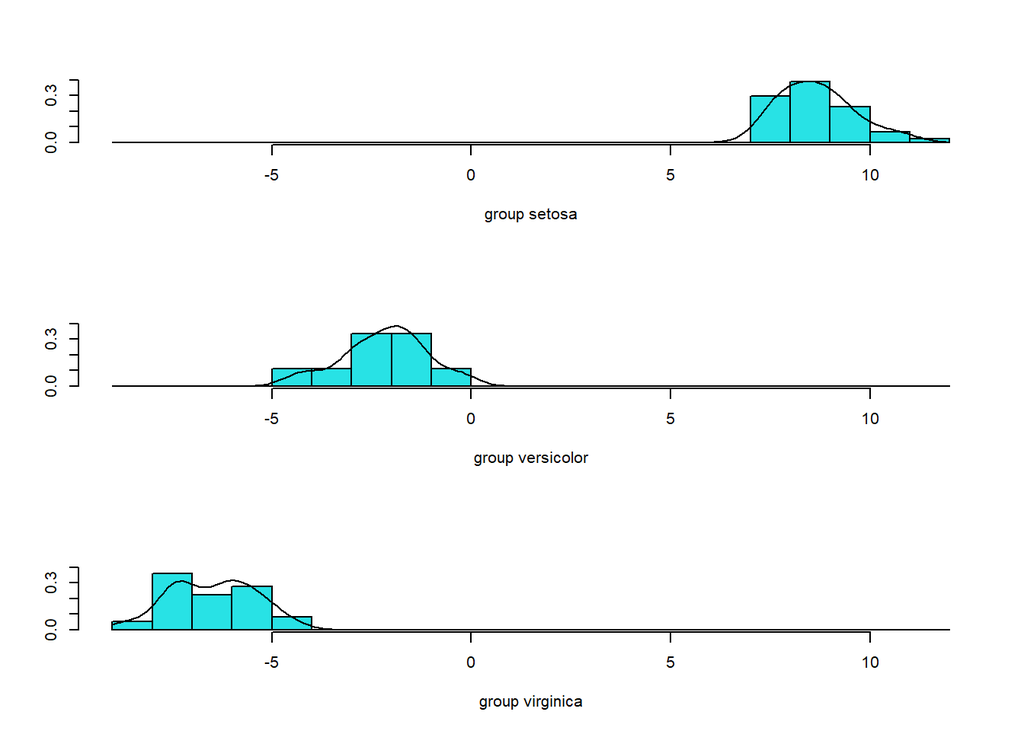

```r
plot(lda.iris, dimen = 1, type = "b")
```

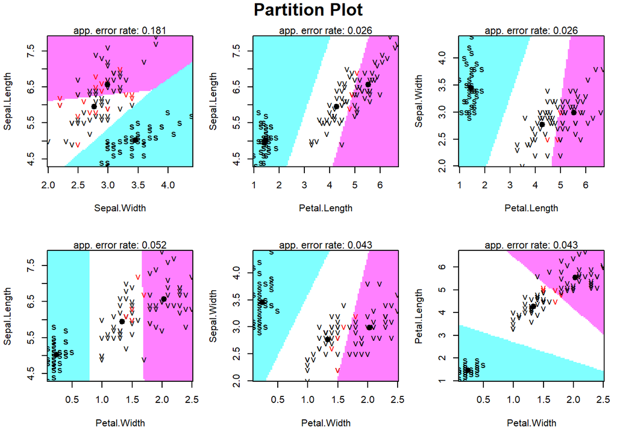

```r
partimat(Species ~ Sepal.Length + Sepal.Width + Petal.Length + Petal.Width, data=train, method="lda")
```

Al analizar los signos y magnitudes de los pesos podemos inferir cuales son las variables mas determinantes en la clasificacion. En este caso parecen ser en la primera funcion la informacion proveniente de los petalos y en la segunda los anchos de petalos y sepalos.

```r
lda.test <- predict(lda.iris,test)
test$lda <- lda.test$class
table(test$lda,test$Species)
```

```
##
##              setosa versicolor virginica
##   setosa          6          0         0
##   versicolor      0         13         0
##   virginica       0          1        14
```

A continuacion realizamos el test M de Box, de homogeniedad en las matrices de covarianza.

```r
library(rstatix)
box_m(iris[, -5], iris[, 5])
```

```
## # A tibble: 1 x 4
##   statistic  p.value parameter method
##       <dbl>    <dbl>     <dbl> <chr>
## 1      141. 3.35e-20        20 Box's M-test for Homogeneity of Covariance Matri~
```

Rechazamos la hipotesis de homocedasticidad, por lo tanto, hacemos una clasificacion discriminante cuadratico y predecimos en la muestra de testeo.

```r
qda.iris = qda(Species ~ Sepal.Length + Sepal.Width + Petal.Length + Petal.Width, train)
qda.iris #mostramos la salida
```

```
## Call:
## qda(Species ~ Sepal.Length + Sepal.Width + Petal.Length + Petal.Width,
##     data = train)
##
## Prior probabilities of groups:
##     setosa versicolor  virginica
##  0.3793103  0.3103448  0.3103448
##
## Group means:
##            Sepal.Length Sepal.Width Petal.Length Petal.Width
## setosa         5.020455    3.454545     1.463636   0.2386364
## versicolor     5.947222    2.766667     4.280556   1.3305556
## virginica      6.572222    2.988889     5.536111   2.0333333
```

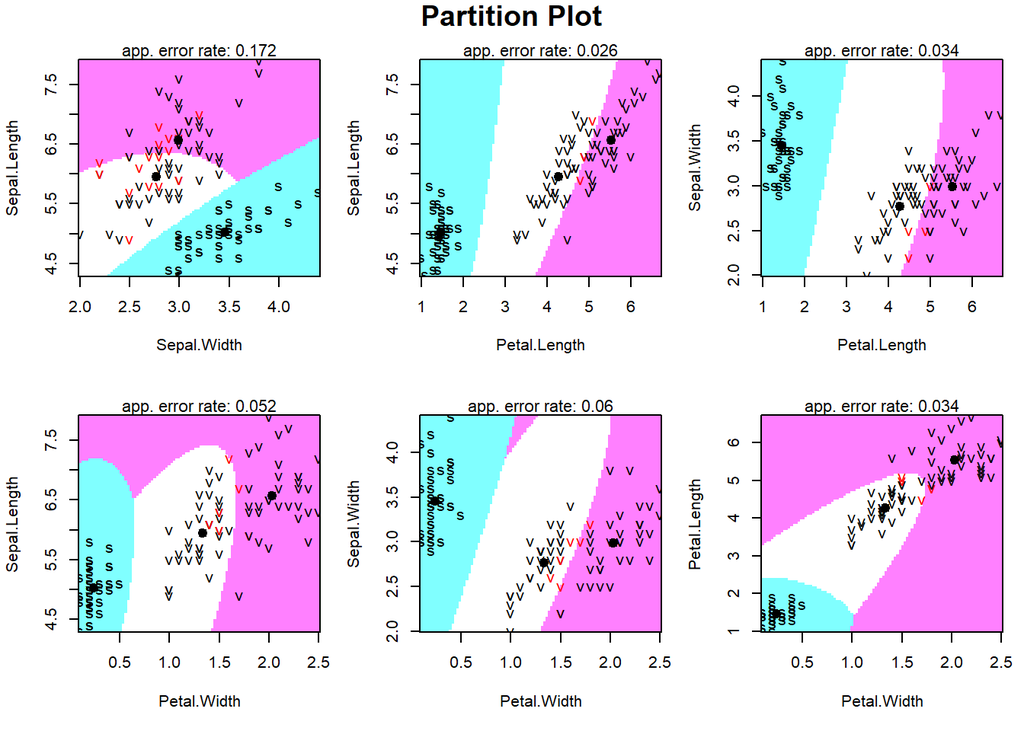

```r
partimat(Species ~ Sepal.Length + Sepal.Width + Petal.Length + Petal.Width, data=train, method="qda")
```

En la salida se puede ver que ya no tenemos mas los pesos discriminantes.

```r
qda.test <- predict(qda.iris,test)
test$qda <- qda.test$class
table(test$qda,test$Species)
```

```
##
##              setosa versicolor virginica
##   setosa          6          0         0
##   versicolor      0         13         0
##   virginica       0          1        14
```

En este caso particular la clasificacion es igual al caso lineal.

```r
library(e1071)
library(naivebayes)
nb.iris <- naiveBayes(Species ~ Sepal.Length + Sepal.Width + Petal.Length + Petal.Width, train)
nbiris.test <- predict(nb.iris,test)
table(nbiris.test,test$Species)
```

```
##
## nbiris.test  setosa versicolor virginica
##   setosa          6          0         0
##   versicolor      0         14         0
##   virginica       0          0        14
```

En este caso particular, la estimacion no tiene errores.

Pasamos ahora a calcular la sensitividad, especificidad, presicion y demas medidas de ajuste de la clasificacion. Lo haremos para el clasificador cuadratico que tuvo al menos un error.

Hay que prestar atencion al modo en que se pone la matriz de confusion en el comando, las predicciones son las columnas.

```r
qda.test = predict(qda.iris,test)
qdairis.test=qda.test$class

tab <- table(test$Species, qdairis.test, dnn =c("Real","Predicha"))
tab
```

```
##             Predicha
## Real         setosa versicolor virginica
##   setosa          6          0         0
##   versicolor      0         13         1
##   virginica       0          0        14
```

```r
library(caret)
cm.nb.iris=confusionMatrix(tab)
cm.nb.iris
```

```
## Confusion Matrix and Statistics
##
##             Predicha
## Real         setosa versicolor virginica
##   setosa          6          0         0
##   versicolor      0         13         1
##   virginica       0          0        14
##
## Overall Statistics
##
##                Accuracy : 0.9706
##                  95% CI : (0.8467, 0.9993)
##     No Information Rate : 0.4412
##     P-Value [Acc > NIR] : 3.639e-11
##
##                   Kappa : 0.9533
##
##  Mcnemar's Test P-Value : NA
##
## Statistics by Class:
##
##                      Class: setosa Class: versicolor Class: virginica
## Sensitivity                 1.0000            1.0000           0.9333
## Specificity                 1.0000            0.9524           1.0000
## Pos Pred Value              1.0000            0.9286           1.0000
## Neg Pred Value              1.0000            1.0000           0.9500
## Prevalence                  0.1765            0.3824           0.4412
## Detection Rate              0.1765            0.3824           0.4118
## Detection Prevalence        0.1765            0.4118           0.4118
## Balanced Accuracy           1.0000            0.9762           0.9667
```

Como tenemos tres categorias muestra las medias (sensitividad, especificidad, etc) para las marginales de cada categoria.

```r
library(mlbench)
data("BreastCancer")
bc=na.omit(BreastCancer[,-1]) #saco los datos faltantes.

set.seed(123)
training_sample <- sample(c(TRUE, FALSE), nrow(bc), replace = T, prob = c(0.75,0.25))
train <- bc[training_sample, ]
test <- bc[!training_sample, ]
```

Hacemos la clasificacion con el discriminante lineal, no nos importa tanto como es la clasificacion en si misma sino ver como se grafica la curva ROC.

```r
lda.bc <- lda(Class ~ ., train)
lda.bc
```

```
## Call:
## lda(Class ~ ., data = train)
##
## Prior probabilities of groups:
##    benign malignant
## 0.6331361 0.3668639
##
## Group means:
##           Cl.thickness.L Cl.thickness.Q Cl.thickness.C Cl.thickness^4
## benign        -0.2793567     0.04229924     0.02885616     0.05813564
## malignant      0.1811263     0.01403852     0.09495694     0.10736811
##           Cl.thickness^5 Cl.thickness^6 Cl.thickness^7 Cl.thickness^8
## benign       -0.10440553     0.04729199  -5.649704e-16     0.04252407
## malignant     0.02502552     0.02574069   8.716194e-02     0.07348884
##           Cl.thickness^9 Cell.size.L Cell.size.Q Cell.size.C Cell.size^4
## benign       -0.04995739  -0.4621647  0.43871908  -0.3373279   0.2264844
## malignant    -0.06351661   0.1349568  0.04960277   0.1484718   0.1033468
##           Cell.size^5 Cell.size^6 Cell.size^7 Cell.size^8   Cell.size^9
## benign    -0.14634622  0.08791460 -0.04751378  0.01485430 -0.0041960817
## malignant  0.05005104  0.06885112  0.05524349  0.03347713  0.0006095644
##           Cell.shape.L Cell.shape.Q Cell.shape.C Cell.shape^4 Cell.shape^5
## benign      -0.4501604   0.40428315   -0.2934383   0.18541659  -0.10987121
## malignant    0.1260781   0.01263467    0.1406361   0.09580693   0.04254338
##           Cell.shape^6 Cell.shape^7 Cell.shape^8 Cell.shape^9 Marg.adhesion.L
## benign      0.06766393  -0.03655187  0.009669857 -0.002825644     -0.45770596
## malignant   0.07659425   0.03437372  0.003217022 -0.018872113      0.01006257
##           Marg.adhesion.Q Marg.adhesion.C Marg.adhesion^4 Marg.adhesion^5
## benign         0.42760197     -0.31940210      0.21745527     -0.13708803
## malignant      0.08750678      0.06483307      0.07067395      0.02098294
##           Marg.adhesion^6 Marg.adhesion^7 Marg.adhesion^8 Marg.adhesion^9
## benign         0.08233657     -0.04441307      0.02289309     -0.01044076
## malignant      0.08705795      0.02581177      0.02432873      0.01594620
##           Epith.c.size.L Epith.c.size.Q Epith.c.size.C Epith.c.size^4
## benign      -0.373676019     0.17163731      0.1124314    -0.31263928
## malignant   -0.000591916    -0.09780169      0.1404039     0.06162608
##           Epith.c.size^5 Epith.c.size^6 Epith.c.size^7 Epith.c.size^8
## benign        0.37423137    -0.30921687    0.190784703    -0.08388309
## malignant     0.01636284     0.01485845    0.001353544     0.06303352
##           Epith.c.size^9 Bare.nuclei2 Bare.nuclei3 Bare.nuclei4 Bare.nuclei5
## benign        0.01935566   0.05295950   0.04049844   0.01557632   0.02492212
```

[output cut: 90 more lines]

```
## Normal.nucleoli4   1.368413132
## Normal.nucleoli5   0.680629338
## Normal.nucleoli6   0.659503470
## Normal.nucleoli7   0.026637341
## Normal.nucleoli8   0.444755067
## Normal.nucleoli9   1.192221544
## Normal.nucleoli10  0.704742430
## Mitoses2           0.403155597
## Mitoses3          -0.064766742
## Mitoses4          -0.430888715
## Mitoses5           0.101563152
## Mitoses6          -0.377044768
## Mitoses7           0.004707886
## Mitoses8           0.007681389
## Mitoses10          0.425887838
```

```r
lda.test.bc <- predict(lda.bc,test)
confusion <- table(test$Class, lda.test.bc$class, dnn = c("Real", "Predicha"))
cm.lda.bc=confusionMatrix(confusion)
cm.lda.bc
```

```
## Confusion Matrix and Statistics
##
##            Predicha
## Real        benign malignant
##   benign       121         2
##   malignant      0        53
##
##                Accuracy : 0.9886
##                  95% CI : (0.9596, 0.9986)
##     No Information Rate : 0.6875
##     P-Value [Acc > NIR] : <2e-16
##
##                   Kappa : 0.9733
##
##  Mcnemar's Test P-Value : 0.4795
##
##             Sensitivity : 1.0000
##             Specificity : 0.9636
##          Pos Pred Value : 0.9837
##          Neg Pred Value : 1.0000
##              Prevalence : 0.6875
##          Detection Rate : 0.6875
##    Detection Prevalence : 0.6989
##       Balanced Accuracy : 0.9818
##
##        'Positive' Class : benign
##
```

A continuacion buscamos la curva ROC, en el eje $x$ tenemos la 1-especificidad (falso positive rate) mientras que en el eje $y$ tenemos sensitividad (true positive rate)

Ademas calculamos el area debajo de la curva.

```r
library(ROCR) #tiene sentido para clasificadores binarios.
#cjto de datos con predicciones y etiquetas verdaderas
df <- data.frame(predictions= as.numeric(lda.test.bc$class),labels=as.numeric(test$Class))
#como factores no funciona
pred <- prediction(as.numeric(df$predictions), df$labels)
perf <- performance(pred,"tpr","fpr")
auc.pred <- performance(pred, measure = "auc")
auc.pred@y.values
```

```
## [[1]]
## [1] 0.9918699
```

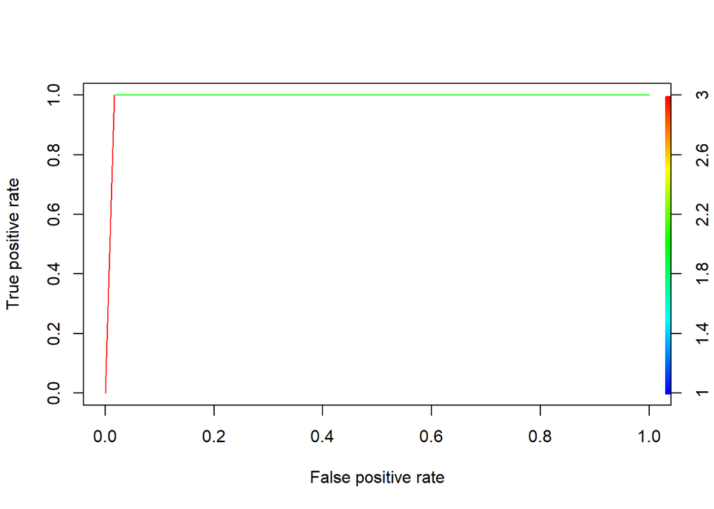

```r
plot(perf,colorize=TRUE)
```